# Variant_classification_analysis

albarcam

2/1/2016

1. All dbNSFP variant files were put together, in cytosine. Columns with the variant possition, the ClinVar pathogenicity description and the prediction tools were selected. The final file is called “dbNSFP3.1a_variant.ClinVar.PathoTools.txt”

In linux:

less dbNSFP3.1a_variant.chr* | awk -F “” ’{if ($139 !~ /./){print $_}}’|cut -f 1,2,3,4,7,26,33,38,42,49,52,55,58,60,63,67,71,74,75,139 > dbNSFP3.1a_variant.ClinVar.PathoTools.txt

grep -v “#” dbNSFP3.1a_variant.ClinVar.PathoTools.txt >> header

mv header dbNSFP3.1a_variant.ClinVar.PathoTools.txt

2. Read the file in R:

```r
#install.packages("car")
library(car)

# put data from all chr together, to filter the variant files, take only the variants annotated in ClinVar and the columns with the patho tools:

pred.clinvar<-read.delim("/external.data/Variants/dbNSFP/dbNSFPv3.1/dbNSFP3.1a/dbNSFP3.1a_variant.ClinVar.PathoTools.txt", sep="\t")

head(pred.clinvar)
```

```
##   chr pos.1.based. ref alt rs_dbSNP144 SIFT_pred Polyphen2_HVAR_score
## 1   1      1014359   G   T rs672601312         .                    .
## 2   1      1041582   C   T rs587777299         .                    .
## 3   1      1041583   A   G rs150359724       .;T                0.009
## 4   1      1044368   A   T rs113288277       .;D                0.986
## 5   1      1046833   G   C rs150132566       .;T                  0.0
## 6   1      1047342   A   G rs142416636       .;D                 0.76
##   LRT_pred MutationTaster_pred MutationAssessor_pred FATHMM_pred
## 1        N                   D                     .           .
## 2        N                   A                     .           .
## 3        N                   N                     N         .;T
## 4        D                   D                     M         .;T
## 5        N                   N                     N         .;T
## 6        N                   D                     L         .;T
##   PROVEAN_pred VEST3_score  CADD_raw          DANN_score
```

[output cut: 20 more lines]

3. Reorganize the columns, and give a new name:

```r
pred.clinvar<-pred.clinvar[,c(1:4,20,5,6:19)]


name<-c("Chr", "Pos","R","A","clinvar_clnsig","rs_dbSNP144","SIFT", "Polyphen2_HVAR","LRT_pred","MutationTaster_pred","MutationAssessor_pred",
         "FATHMM", "PROVEAN","VEST3","CADD", "DANN", "fathmm.MKL","MetaSVM","MetaLR_pred","Reliability_index")
name
```

```
##  [1] "Chr"                   "Pos"
##  [3] "R"                     "A"
##  [5] "clinvar_clnsig"        "rs_dbSNP144"
##  [7] "SIFT"                  "Polyphen2_HVAR"
##  [9] "LRT_pred"              "MutationTaster_pred"
## [11] "MutationAssessor_pred" "FATHMM"
## [13] "PROVEAN"               "VEST3"
## [15] "CADD"                  "DANN"
## [17] "fathmm.MKL"            "MetaSVM"
## [19] "MetaLR_pred"           "Reliability_index"
```

```r
colnames(pred.clinvar)<-name

head(pred.clinvar,n = 10 )
```

```
##    Chr     Pos R A clinvar_clnsig rs_dbSNP144 SIFT Polyphen2_HVAR LRT_pred
## 1    1 1014359 G T              5 rs672601312    .              .        N
## 2    1 1041582 C T              5 rs587777299    .              .        N
## 3    1 1041583 A G              3 rs150359724  .;T          0.009        N
## 4    1 1044368 A T              2 rs113288277  .;D          0.986        D
## 5    1 1046833 G C              3 rs150132566  .;T            0.0        N
## 6    1 1047342 A G              3 rs142416636  .;D           0.76        N
## 7    1 1048126 C T              3 rs139294803  .;T            0.0        N
## 8    1 1048224 C T              3 rs184970403  .;T          0.332        N
## 9    1 1049591 G A              3 rs111818381  .;T          0.001        N
## 10   1 1050446 G A              3  rs17160775  .;T          0.037        U
##    MutationTaster_pred MutationAssessor_pred FATHMM PROVEAN VEST3
## 1                    D                     .      .       .     .
## 2                    A                     .      .       .     .
## 3                    N                     N    .;T     .;N 0.024
```

[output cut: 29 more lines]

```r
summary(pred.clinvar)
```

```
##       Chr             Pos            R         A        clinvar_clnsig
##  X      : 2846   Min.   :     3308   A: 4267   A:9556   Min.   :-6.000
##  2      : 2661   1st Qu.: 32644229   C:10011   C:4991   1st Qu.: 4.000
##  11     : 2139   Median : 52397797   G:10359   G:4926   Median : 5.000
##  3      : 2079   Mean   : 75525025   T: 4199   T:9363   Mean   : 4.437
##  1      : 2045   3rd Qu.:112837608                      3rd Qu.: 5.000
##  17     : 1815   Max.   :247425329                      Max.   : 6.000
##  (Other):15251
##       rs_dbSNP144         SIFT       Polyphen2_HVAR  LRT_pred
##  .          :   84   D      :11668   .      : 7088   .: 4275
##  rs121913101:    6   .      : 7354   1.0    : 2881   D:16500
##  rs121913103:    6   T      : 3743   0.999  : 1094   N: 6660
##  rs80338792 :    6   D;.    :  531   0.0    :  640   U: 1401
##  rs104894623:    4   D;D;.  :  324   0.998  :  458
##  rs267606716:    4   D;.;D  :  267   0.001  :  332
##  (Other)    :28726   (Other): 4949   (Other):16343
##  MutationTaster_pred MutationAssessor_pred     FATHMM        PROVEAN
##  A;A    : 3463       .:7620                .      :7139   D      :10949
##  D;D    : 3307       H:4927                D      :3823   .      : 7121
##  D      : 2825       L:4153                D;D    :3554   N      : 5029
##  A      : 2768       M:8828                T      :2101   D;.    :  496
##  A;A;A  : 1898       N:3308                T;T    :1626   D;D;.  :  296
##  D;D;D  : 1816                             D;D;D  :1323   N;.    :  261
##  (Other):12759                             (Other):9270   (Other): 4684
##          VEST3            CADD                         DANN
##  .          : 7030   Min.   :-5.477   .                  :   92
##  0.988;0.988:   24   1st Qu.: 3.957   0.99073202916593972:    3
##  0.994;0.994:   24   Median : 5.717   0.99376333737019606:    3
##  0.995;0.995:   23   Mean   : 5.841   0.99855093143298301:    3
##  0.969;0.969:   22   3rd Qu.: 7.043   0.25316120315982604:    2
##  0.985;0.985:   21   Max.   :33.577   0.47224593445469865:    2
##  (Other)    :21692                    (Other)            :28731
##  fathmm.MKL MetaSVM   MetaLR_pred Reliability_index
##  .:   92    .: 6949   .: 6949     10     :12175
##  D:24402    D:14294   D:14405     9      : 8500
##  N: 4342    T: 7593   T: 7482     .      : 6949
##                                   8      :  922
##                                   6      :  122
##                                   7      :  122
##                                   (Other):   46
```

4. Replace all the predictions by: disease causing = 1, tolerated=-1, unknown=0;

5. create a loop to replace letters by 0, -1 and 1. The recode and which.max functions are used for selecting the most pathogenic score, when there are multiple predictions

```r
list.pred<-list("")
list.pred
```

```
## [[1]]
## [1] ""
```

```r
new.x<-list("")
z=1
for (i in c(7,9:13,17:19))
  {

  pred.clinvar[,i]
  x<-strsplit(as.character(pred.clinvar[,i]),";")
  head(x, n=10)
  length(x)

        for (r in 1:length(x))
          {

          a<-x[r][[1]][
            which.max(recode(x[r][[1]],"c('T','N','P','L')='-1';c('D','A','H','M')='1';c('.','U')='0'"))
            ]
          #x[10][[1]][2]
          new.x[r]<-unlist(a)

          #head(a)
          #head(new.x)


          #length(new.x)
          #head(new.x)
          #new.x[6]
          #name[7]

        }


  list.pred[z]<-list(new.x)
  z<-z+1
  }
```

6. To give a name to each list

```r
names(list.pred)<-name[c(7,9:13,17:19)]
summary(list.pred)
```

```
##                       Length Class  Mode
## SIFT                  28836  -none- list
## LRT_pred              28836  -none- list
## MutationTaster_pred   28836  -none- list
## MutationAssessor_pred 28836  -none- list
## FATHMM                28836  -none- list
## PROVEAN               28836  -none- list
## fathmm.MKL            28836  -none- list
## MetaSVM               28836  -none- list
## MetaLR_pred           28836  -none- list
```

7. To replace the letters describing the pathogenicity predictions by numbers (-1, 0, 1). It is also possible to do it in the previous loop, but R takes forever…

```r
list.pred$SIFT<-recode(list.pred$SIFT,"c('T','N','P','L')='-1';c('D','A','H','M')='1';c('.','U')='0'")

list.pred$LRT_pred<-recode(list.pred$LRT_pred,"c('T','N','P','L')='-1';c('D','A','H','M')='1';c('.','U')='0'")

list.pred$MutationTaster_pred<-recode(list.pred$MutationTaster_pred,"c('T','N','P','L')='-1';c('D','A','H','M')='1';c('.','U')='0'")

list.pred$MutationAssessor_pred<-recode(list.pred$MutationAssessor_pred,"c('T','N','P','L')='-1';c('D','A','H','M')='1';c('.','U')='0'")

list.pred$FATHMM<-recode(list.pred$FATHMM,"c('T','N','P','L')='-1';c('D','A','H','M')='1';c('.','U')='0'")

list.pred$PROVEAN<-recode(list.pred$PROVEAN,"c('T','N','P','L')='-1';c('D','A','H','M')='1';c('.','U')='0'")

list.pred$fathmm.MKL<-recode(list.pred$fathmm.MKL,"c('T','N','P','L')='-1';c('D','A','H','M')='1';c('.','U')='0'")

list.pred$MetaSVM<-recode(list.pred$MetaSVM,"c('T','N','P','L')='-1';c('D','A','H','M')='1';c('.','U')='0'")

list.pred$MetaLR_pred<- recode(list.pred$MetaLR_pred,"c('T','N','P','L')='-1';c('D','A','H','M')='1';c('.','U')='0'")
```

8. To convert the list of lists to a dataframe

```r
pred.w<- data.frame(lapply(data.frame((sapply(list.pred, `[`))), unlist))

head(pred.w)
```

```
##   SIFT LRT_pred MutationTaster_pred MutationAssessor_pred FATHMM PROVEAN
## 1    0       -1                   1                     0      0       0
## 2    0       -1                   1                     0      0       0
## 3    0       -1                  -1                    -1      0       0
## 4    1        1                   1                     1      0       1
## 5    0       -1                  -1                    -1      0       0
## 6    1       -1                   1                    -1      0       0
##   fathmm.MKL MetaSVM MetaLR_pred
## 1         -1       0           0
## 2         -1       0           0
## 3         -1      -1          -1
## 4          1      -1          -1
## 5         -1      -1          -1
## 6          1      -1          -1
```

9. Now, for the patho tools with scores. If there is more than one score for one variant, the maximun score was chosen.We still need to decide which score we will accept for a predicted pathogenic variant. Empty values were converted to -1e+19:

```r
list.pred2<-list("")
list.pred2
```

```
## [[1]]
## [1] ""
```

```r
new.x<-list("")
z=1
for (i in c(8,14,15,16))
  {
  i=8
  pred.clinvar[,i]
  x<-strsplit(as.character(pred.clinvar[,i]),";")
  x[x=="."]<- -9999999999999999999


  for (r in 1:length(x))
    {
      a<-max((x[r][[1]]))
      new.x[r]<-unlist(a)
    }

  list.pred2[z]<-list(new.x)
  z<-z+1
}
```

10. To give a name to each list

```r
names(list.pred2)<-name[c(8,14,15,16)]
summary(list.pred2)
```

```
##                Length Class  Mode
## Polyphen2_HVAR 28836  -none- list
## VEST3          28836  -none- list
## CADD           28836  -none- list
## DANN           28836  -none- list
```

11. To convert PolyPhen score to -1, 0 and 1:

```r
list.pred2$Polyphen2_HVAR[list.pred2$Polyphen2_HVAR >= 0.0  & list.pred2$Polyphen2_HVAR < 0.47] <- -1
list.pred2$Polyphen2_HVAR[list.pred2$Polyphen2_HVAR >= 0.47] <- 1
list.pred2$Polyphen2_HVAR[list.pred2$Polyphen2_HVAR == -1e+19] <- 0
```

11. To convert the list of lists in data.frame

```r
pred.w2<- data.frame(lapply(data.frame((sapply(list.pred2, `[`))), unlist))

head(pred.w2)
```

```
##   Polyphen2_HVAR  VEST3   CADD   DANN
## 1              0 -1e+19 -1e+19 -1e+19
## 2              0 -1e+19 -1e+19 -1e+19
## 3             -1  0.009  0.009  0.009
## 4              1  0.986  0.986  0.986
## 5             -1    0.0    0.0    0.0
## 6              1   0.76   0.76   0.76
```

```r
summary(pred.w2)
```

```
##  Polyphen2_HVAR       VEST3            CADD            DANN
##  Min.   :-1.000   -1e+19 : 7088   -1e+19 : 7088   -1e+19 : 7088
##  1st Qu.: 0.000   1.0    : 4375   1.0    : 4375   1.0    : 4375
##  Median : 1.000   0.999  : 2082   0.999  : 2082   0.999  : 2082
##  Mean   : 0.348   0.998  :  905   0.998  :  905   0.998  :  905
##  3rd Qu.: 1.000   0.0    :  640   0.0    :  640   0.0    :  640
##  Max.   : 1.000   0.997  :  522   0.997  :  522   0.997  :  522
##                   (Other):13224   (Other):13224   (Other):13224
```

12. To save a table with the selected/modified scores:

```r
pred.w.CV<-data.frame(pred.clinvar[,1:5], pred.w, pred.w2)
write.table(pred.w.CV, file ="/home/albarcam/data00.me/ClinVar/Transformed_prediction_scores.txt", row.names = FALSE, quote = FALSE, col.names = TRUE, sep="\t")
```

**Let’s look at some correlations

1. Read the file with the transformed scores:

```r
data<-read.table("/home/albarcam/data00.me/ClinVar/Transformed_prediction_scores.txt", header=TRUE)
```

2. Choose the rows with ClinVar data classified as (likely)pathogenic or (likely)bening. Then convert clinvar scores to 1 and -1 and check the correlation with the prediction tools:

```r
ppatho<-data[data$clinvar_clnsig <= 5 & data$clinvar_clnsig >= 2,5:15]

summary((ppatho))
```

```
##  clinvar_clnsig      SIFT            LRT_pred       MutationTaster_pred
##  Min.   :2.00   Min.   :-1.0000   Min.   :-1.0000   Min.   :-1.0000
##  1st Qu.:4.00   1st Qu.: 0.0000   1st Qu.: 0.0000   1st Qu.: 1.0000
##  Median :5.00   Median : 1.0000   Median : 1.0000   Median : 1.0000
##  Mean   :4.44   Mean   : 0.4327   Mean   : 0.3421   Mean   : 0.7304
##  3rd Qu.:5.00   3rd Qu.: 1.0000   3rd Qu.: 1.0000   3rd Qu.: 1.0000
##  Max.   :5.00   Max.   : 1.0000   Max.   : 1.0000   Max.   : 1.0000
##  MutationAssessor_pred     FATHMM           PROVEAN
##  Min.   :-1.0000       Min.   :-1.0000   Min.   :-1.0000
##  1st Qu.:-1.0000       1st Qu.: 0.0000   1st Qu.: 0.0000
##  Median : 0.0000       Median : 0.0000   Median : 1.0000
##  Mean   : 0.2189       Mean   : 0.3093   Mean   : 0.3409
##  3rd Qu.: 1.0000       3rd Qu.: 1.0000   3rd Qu.: 1.0000
##  Max.   : 1.0000       Max.   : 1.0000   Max.   : 1.0000
##    fathmm.MKL         MetaSVM         MetaLR_pred      Polyphen2_HVAR
##  Min.   :-1.0000   Min.   :-1.0000   Min.   :-1.0000   Min.   :-1.0000
##  1st Qu.: 1.0000   1st Qu.:-1.0000   1st Qu.:-1.0000   1st Qu.: 0.0000
##  Median : 1.0000   Median : 0.0000   Median : 1.0000   Median : 1.0000
##  Mean   : 0.6972   Mean   : 0.2338   Mean   : 0.2415   Mean   : 0.3487
##  3rd Qu.: 1.0000   3rd Qu.: 1.0000   3rd Qu.: 1.0000   3rd Qu.: 1.0000
##  Max.   : 1.0000   Max.   : 1.0000   Max.   : 1.0000   Max.   : 1.0000
```

```r
ppatho$clinvar_clnsig[ppatho$clinvar_clnsig ==5] <- 1
ppatho$clinvar_clnsig[ppatho$clinvar_clnsig == 4]<-1

ppatho$clinvar_clnsig[ppatho$clinvar_clnsig == 3]<- -1
ppatho$clinvar_clnsig[ppatho$clinvar_clnsig == 2]<- -1

cor(ppatho)
```

```
##                       clinvar_clnsig      SIFT  LRT_pred
## clinvar_clnsig             1.0000000 0.3121438 0.3564944
## SIFT                       0.3121438 1.0000000 0.3782603
## LRT_pred                   0.3564944 0.3782603 1.0000000
## MutationTaster_pred        0.6167155 0.3512640 0.4416754
## MutationAssessor_pred      0.4105231 0.5482871 0.4073095
## FATHMM                     0.2661213 0.3215566 0.2363865
## PROVEAN                    0.3774252 0.6535969 0.4140297
## fathmm.MKL                 0.3900762 0.3542291 0.4926259
## MetaSVM                    0.5298843 0.5058833 0.4283385
## MetaLR_pred                0.5072207 0.4645447 0.3904847
## Polyphen2_HVAR             0.4275129 0.6014610 0.4651787
##                       MutationTaster_pred MutationAssessor_pred    FATHMM
## clinvar_clnsig                  0.6167155             0.4105231 0.2661213
## SIFT                            0.3512640             0.5482871 0.3215566
## LRT_pred                        0.4416754             0.4073095 0.2363865
## MutationTaster_pred             1.0000000             0.4159789 0.2371955
## MutationAssessor_pred           0.4159789             1.0000000 0.2777520
## FATHMM                          0.2371955             0.2777520 1.0000000
## PROVEAN                         0.3968173             0.6016083 0.3281245
## fathmm.MKL                      0.5645187             0.3574090 0.2149654
## MetaSVM                         0.4919011             0.5676351 0.6007682
## MetaLR_pred                     0.4450947             0.5251633 0.6492027
## Polyphen2_HVAR                  0.4665866             0.5859636 0.3023022
##                         PROVEAN fathmm.MKL   MetaSVM MetaLR_pred
## clinvar_clnsig        0.3774252  0.3900762 0.5298843   0.5072207
## SIFT                  0.6535969  0.3542291 0.5058833   0.4645447
## LRT_pred              0.4140297  0.4926259 0.4283385   0.3904847
## MutationTaster_pred   0.3968173  0.5645187 0.4919011   0.4450947
## MutationAssessor_pred 0.6016083  0.3574090 0.5676351   0.5251633
## FATHMM                0.3281245  0.2149654 0.6007682   0.6492027
## PROVEAN               1.0000000  0.3693769 0.5310250   0.4858219
## fathmm.MKL            0.3693769  1.0000000 0.4002877   0.3629686
## MetaSVM               0.5310250  0.4002877 1.0000000   0.9162788
## MetaLR_pred           0.4858219  0.3629686 0.9162788   1.0000000
## Polyphen2_HVAR        0.6023047  0.4325272 0.5874221   0.5452634
##                       Polyphen2_HVAR
## clinvar_clnsig             0.4275129
## SIFT                       0.6014610
## LRT_pred                   0.4651787
## MutationTaster_pred        0.4665866
## MutationAssessor_pred      0.5859636
## FATHMM                     0.3023022
## PROVEAN                    0.6023047
## fathmm.MKL                 0.4325272
## MetaSVM                    0.5874221
## MetaLR_pred                0.5452634
## Polyphen2_HVAR             1.0000000
```

3. How many undefined values for each prediction tool (score = 0):

```r
dim(ppatho)
```

```
## [1] 28795    11
```

```r
dim(ppatho[ppatho$SIFT == 0,])
```

```
## [1] 8882   11
```

```r
dim(ppatho[ppatho$LRT_pred == 0,])
```

```
## [1] 5671   11
```

```r
dim(ppatho[ppatho$MutationTaster_pred == 0,])
```

```
## [1] 117  11
```

```r
dim(ppatho[ppatho$MutationAssessor_pred == 0,])
```

```
## [1] 7607   11
```

```r
dim(ppatho[ppatho$FATHMM == 0,])
```

```
## [1] 8981   11
```

```r
dim(ppatho[ppatho$PROVEAN == 0,])
```

```
## [1] 8960   11
```

```r
dim(ppatho[ppatho$fathmm.MKL == 0,])
```

```
## [1] 92 11
```

```r
dim(ppatho[ppatho$MetaSVM == 0,])
```

```
## [1] 6946   11
```

```r
dim(ppatho[ppatho$Polyphen2_HVAR == 0,])
```

```
## [1] 7082   11
```

4. How well the sum of prediction tools classify clinvar variants, just a visualization with boxplots

4.1 Sift, Mutation Taster and Polyphen. This is our actual selection in the classification algorithm

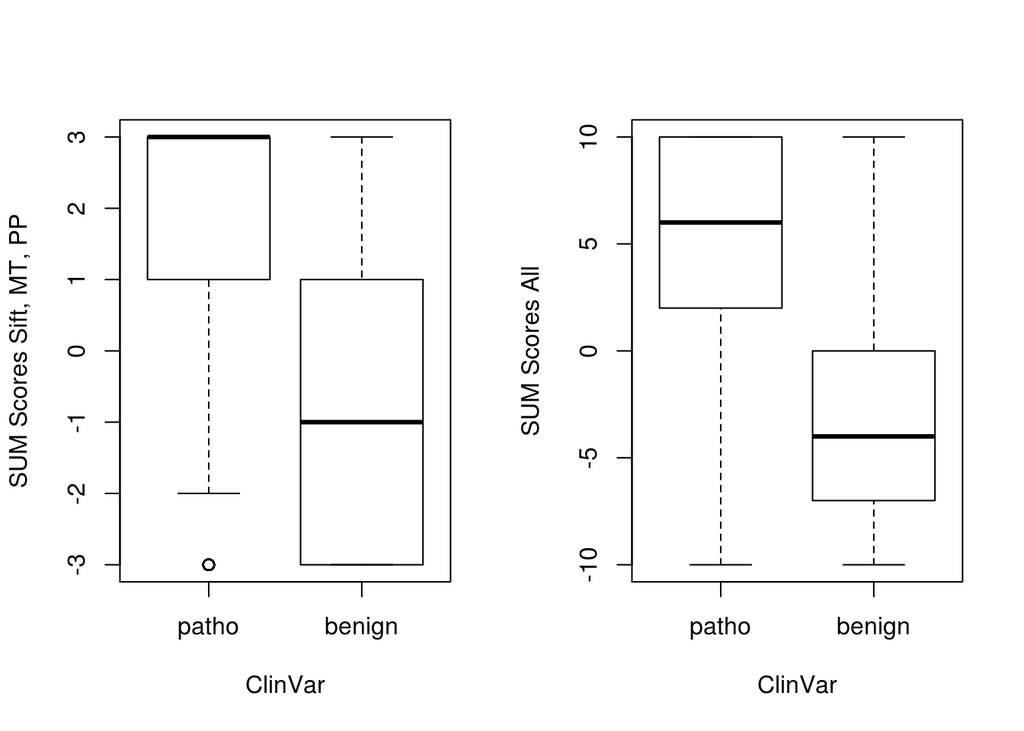

```r
data.s3<-data.frame("CV"=ppatho$clinvar_clnsig,"SumScores1"=apply(ppatho[c(2,4,11)],1,sum))

data.s<-data.frame("CV"=ppatho$clinvar_clnsig,"SumScores1"=apply(ppatho[2:11],1,sum))

par(mfrow=c(1,2))

boxplot(data.s3[data.s3$CV==1,2], data.s3[data.s3$CV==-1,2],  names = c("patho","benign"), xlab="ClinVar", ylab="SUM Scores Sift, MT, PP")

boxplot(data.s[data.s$CV==1,2],  data.s[data.s$CV==-1,2],  names = c("patho","benign"), xlab="ClinVar", ylab="SUM Scores All")
```